# Data_Summary

[Spencer Castro](http://spencercastro.com)

2/6/2017

# DRT Simple Task

1.a This is a plot for the accuracy of the visual search task (The proportion of trials in which a target was selected compared to a distractor.)

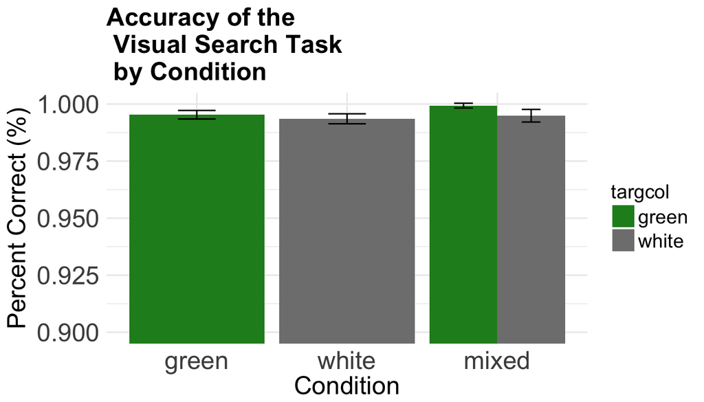

```r
###Colors for plots
####Create a custom color scale
myColors <- c("forestgreen","grey50")
names(myColors) <- levels(clean$targcol)
colScale <- scale_colour_manual(name = "targcol",values = myColors)

acc.mean <- cleanac %>%
  group_by(condition, targcol) %>%
  summarise(perc_corr = mean(corr)*100)


datac <- summarySEwithin(cleanac, measurevar ="corr", withinvars = c("condition","targcol"), idvar = "subid")

accplot <- ggplot(datac, aes(x = condition, y=corr, fill = targcol)) +
  geom_bar(stat = "identity", position = "dodge") + theme_minimal() +
  my.axis.font + geom_errorbar(position=position_dodge(.9), width = .25,
                               aes(ymin=corr-ci, ymax=corr+ci)) +
  xlab("Condition") + coord_cartesian(ylim = c(.9, 1)) +
  scale_fill_manual(values=myColors) + ylab("Percent Correct (%)") +
  ggtitle("Accuracy of the \n Visual Search Task \n by Condition")
accplot
```

```r
vis.ac <- lmer(corr~condition*targcol+(1|subid),data=cleanac)
Anova(vis.ac)
```

```
## Analysis of Deviance Table (Type II Wald chisquare tests)
##
## Response: corr
##                    Chisq Df Pr(>Chisq)
## condition         7.2690  2    0.02640 *
## targcol           6.0906  1    0.01359 *
## condition:targcol         0
## ---
## Signif. codes:  0 '***' 0.001 '**' 0.01 '*' 0.05 '.' 0.1 ' ' 1
```

| condition | target color | percent correct | ci |
| --- | --- | --- | --- |
| green | green | 0.9953 | 0.0018 |
| mixed | green | 0.9993 | 0.0010 |
| mixed | white | 0.9948 | 0.0027 |
| white | white | 0.9935 | 0.0021 |

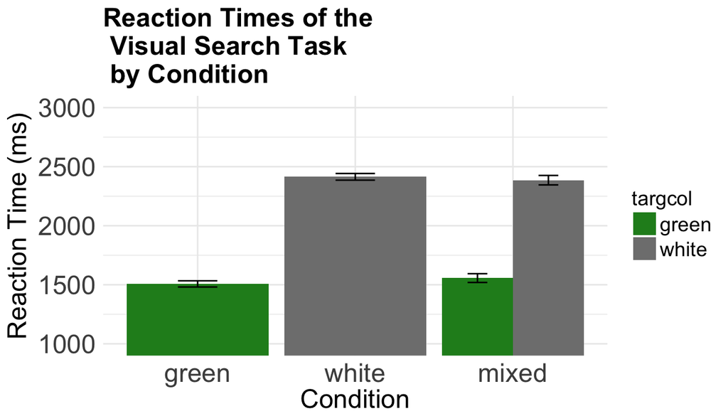

```r
datrt <- summarySEwithin(clean, measurevar ="rt1", withinvars = c("condition","targcol"), idvar = "subid")

rtplot <- ggplot(datrt, aes(x = condition, y=rt1, fill = targcol)) +
  geom_bar(stat = "identity", position = "dodge") + theme_minimal() +
  my.axis.font + geom_errorbar(position=position_dodge(.9), width = .25,
                               aes(ymin=rt1-ci, ymax=rt1+ci)) +
  xlab("Condition") + coord_cartesian(ylim = c(1000, 3000)) +
  scale_fill_manual(values=myColors) + ylab("Reaction Time (ms)") +
  ggtitle("Reaction Times of the \n Visual Search Task \n by Condition")
rtplot
```

```r
vis.ac <- lmer(rt1~condition*targcol*corr+(1|subid),data=clean)
Anova(vis.ac)
```

```
## Analysis of Deviance Table (Type II Wald chisquare tests)
##
## Response: rt1
##                            Chisq Df Pr(>Chisq)
## condition                 6.6690  2    0.03563 *
## targcol                1036.9009  1    < 2e-16 ***
## corr                      5.4530  1    0.01954 *
## condition:targcol                 0
## condition:corr            1.0067  2    0.60449
## targcol:corr              0.6065  1    0.43612
## condition:targcol:corr            0
## ---
## Signif. codes:  0 '***' 0.001 '**' 0.01 '*' 0.05 '.' 0.1 ' ' 1
```

Reaction time was affected by whether the targets were blocked or mixed (condition), the target color was different, or whether the answer was correct or not. There were no interaction effects.

### combined steering with drt

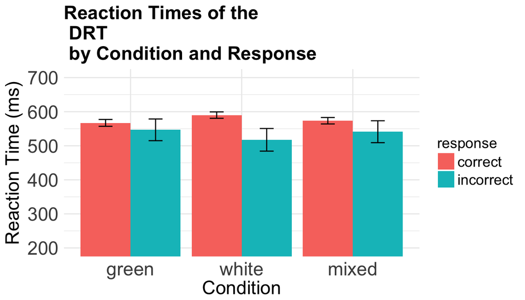

```r
drt.clean$condition <- recode_factor(drt.clean$condition,
                                     "1" = "practice","2" = "green","3" ="white", "4" = "mixed",
                                     .default = "NA")
drt.clean$response <- recode_factor(drt.clean$response, "1" = "correct", "-1" = "incorrect")

drtrt <- summarySEwithin(drt.clean, measurevar ="rt", withinvars = c("condition","response"), idvar = "subid")

drtrt <- drtrt %>% filter(condition != "practice")

rtplot <- ggplot(drtrt, aes(x = condition, y=rt, fill = response)) +
  geom_bar(stat = "identity", position = "dodge") + theme_minimal() +
  my.axis.font + geom_errorbar(position=position_dodge(.9), width = .25,
                               aes(ymin=rt-ci, ymax=rt+ci)) +
  xlab("Condition") + coord_cartesian(ylim = c(200, 700)) + ylab("Reaction Time (ms)") +
  ggtitle("Reaction Times of the \n DRT \n by Condition and Response")
rtplot
```

```r
drt.rt <- lmer(rt~condition*response*mean.dev+(1|subid),data=drt.clean)
Anova(drt.rt)
```

```
## Analysis of Deviance Table (Type II Wald chisquare tests)
##
## Response: rt
##                                 Chisq Df Pr(>Chisq)
## condition                   1942.1371  3  < 2.2e-16 ***
## response                      12.1271  1  0.0004969 ***
## mean.dev                       1.2296  1  0.2674931
## condition:response             6.1538  3  0.1043621
## condition:mean.dev            25.0049  3   1.54e-05 ***
## response:mean.dev              0.1357  1  0.7126094
## condition:response:mean.dev    1.7994  3  0.6150572
## ---
## Signif. codes:  0 '***' 0.001 '**' 0.01 '*' 0.05 '.' 0.1 ' ' 1
```

| condition | response | rt | ci |
| --- | --- | --- | --- |
| green | correct | 567.1133 | 10.026026 |
| green | incorrect | 546.7265 | 31.821575 |
| mixed | correct | 573.4649 | 9.423457 |
| mixed | incorrect | 541.2416 | 32.182574 |
| white | correct | 589.9847 | 9.402508 |
| white | incorrect | 517.4245 | 33.214033 |

Incorrect responses (where the participant responded to the light more than once) were faster on average than correct responses. The difficulty also affected reaction times. In addition, there was a difficulty (condition) by steering deviation interaction. We can see the effect of difficulty on steering below.

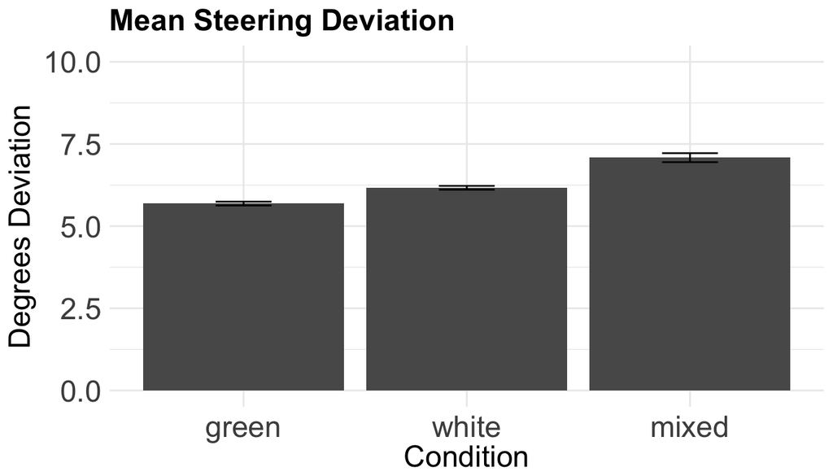

```r
drtrt <- summarySEwithin(drt.clean, measurevar ="mean.dev", withinvars = c("condition"), idvar = "subid")

drtrt <- drtrt %>% filter(condition != "practice")

rtplot <- ggplot(drtrt, aes(x = condition, y=mean.dev)) +
  geom_bar(stat = "identity", position = "dodge") + theme_minimal() +
  my.axis.font + geom_errorbar(position=position_dodge(.9), width = .25,
                               aes(ymin=mean.dev-ci, ymax=mean.dev+ci)) +
  xlab("Condition") + coord_cartesian(ylim = c(0, 10)) + ylab("Degrees Deviation") +
  ggtitle("Mean Steering Deviation")
rtplot
```

```r
drt.rt <- lmer(mean.dev~condition+(1|subid),data=drt.clean)
Anova(drt.rt)
```

[output not shown]

| condition | mean.dev | ci |
| --- | --- | --- |
| green | 5.687147 | 0.059 |
| mixed | 7.083614 | 0.137 |
| white | 6.167213 | 0.057 |

Alone, the effects of the difficulty of the visual task changed the steering deviation so that (1) at the easiest difficulty, steering was best (2) at the highest difficulty, steering was slightly worse, but (3) when participants didn’t know whether to expect easy or difficult trials, steering was the worst. Interestingly, the DRT was not sensitive to this phenomenon.

# DRT Choice Task Data

1.a This is a plot for the accuracy of the visual search task (The proportion of trials in which a target was selected compared to a distractor.)

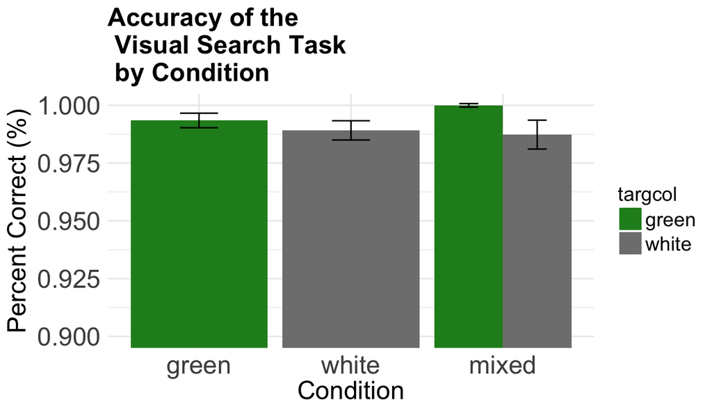

```r
###Colors for plots
####Create a custom color scale
myColors <- c("forestgreen","grey50")
names(myColors) <- levels(clean.choice$targcol)
colScale <- scale_colour_manual(name = "targcol",values = myColors)
clean.choice <- clean.choice %>%
  dplyr::filter(subid != "01", subid != "02", subid != "03")
clean.choiceac <- clean.choiceac %>%
  dplyr::filter(subid != "01", subid != "02", subid != "03")

acc.mean <- clean.choiceac %>%
  group_by(condition, targcol) %>%
  summarise(perc_corr = mean(corr)*100)


datac <- summarySEwithin(clean.choiceac, measurevar ="corr", withinvars = c("condition","targcol"), idvar = "subid")

accplot <- ggplot(datac, aes(x = condition, y=corr, fill = targcol)) +
  geom_bar(stat = "identity", position = "dodge") + theme_minimal() +
  my.axis.font + geom_errorbar(position=position_dodge(.9), width = .25,
                               aes(ymin=corr-ci, ymax=corr+ci)) +
  xlab("Condition") + coord_cartesian(ylim = c(.9, 1)) +
  scale_fill_manual(values=myColors) + ylab("Percent Correct (%)") +
  ggtitle("Accuracy of the \n Visual Search Task \n by Condition")
accplot
```

```r
vis.ac <- lmer(corr~condition*targcol+(1|subid),data=clean.choiceac)
Anova(vis.ac)
```

```
## Analysis of Deviance Table (Type II Wald chisquare tests)
##
## Response: corr
##                    Chisq Df Pr(>Chisq)
## condition          5.905  2  0.0522087 .
## targcol           14.374  1  0.0001498 ***
## condition:targcol         0
## ---
## Signif. codes:  0 '***' 0.001 '**' 0.01 '*' 0.05 '.' 0.1 ' ' 1
```

The ANOVA here shows that the conditions of blocked and mixed difficulties did not impact the accuracy. We have a significant effect of the target color, and it didn’t matter whether the targets were blocked or mixed.

| condition | target color | percent correct | ci |
| --- | --- | --- | --- |
| green | green | 0.9932 | 0.0030 |
| mixed | green | 1.0000 | 0.0007 |
| mixed | white | 0.9875 | 0.0059 |
| white | white | 0.9897 | 0.0038 |

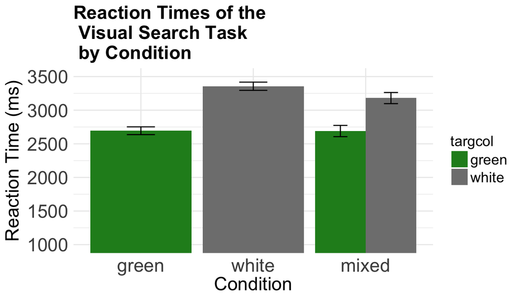

```r
datrt <- summarySEwithin(clean.choice, measurevar ="rt1", withinvars = c("condition","targcol"), idvar = "subid")

rtplot <- ggplot(datrt, aes(x = condition, y=rt1, fill = targcol)) +
  geom_bar(stat = "identity", position = "dodge") + theme_minimal() +
  my.axis.font + geom_errorbar(position=position_dodge(.9), width = .25,
                               aes(ymin=rt1-ci, ymax=rt1+ci)) +
  xlab("Condition") + coord_cartesian(ylim = c(1000, 3500)) +
  scale_fill_manual(values=myColors) + ylab("Reaction Time (ms)") +
  ggtitle("Reaction Times of the \n Visual Search Task \n by Condition")
rtplot
```

```r
vis.ac <- lmer(rt1~condition*targcol*corr+(1|subid),data=clean.choice)
Anova(vis.ac)
```

```
## Analysis of Deviance Table (Type II Wald chisquare tests)
##
## Response: rt1
##                          Chisq Df Pr(>Chisq)
## condition              14.5131  2  0.0007055 ***
## targcol                78.1753  1  < 2.2e-16 ***
## corr                    7.0844  1  0.0077758 **
## condition:targcol               0
## condition:corr          8.0654  2  0.0177267 *
## targcol:corr                    0
## condition:targcol:corr          0
## ---
## Signif. codes:  0 '***' 0.001 '**' 0.01 '*' 0.05 '.' 0.1 ' ' 1
```

Reaction time was affected by whether the targets were blocked or mixed (condition), the target color was different, or whether the answer was correct or not. There was also an interaction of condition and correct/incorrect responses.

| condition | target color | reaction time | ci |
| --- | --- | --- | --- |
| green | green | 2694 | 57.76 |
| mixed | green | 2689 | 83.87 |
| mixed | white | 3180 | 82.75 |
| white | white | 3356 | 61.23 |

### correct drt vs missed drts

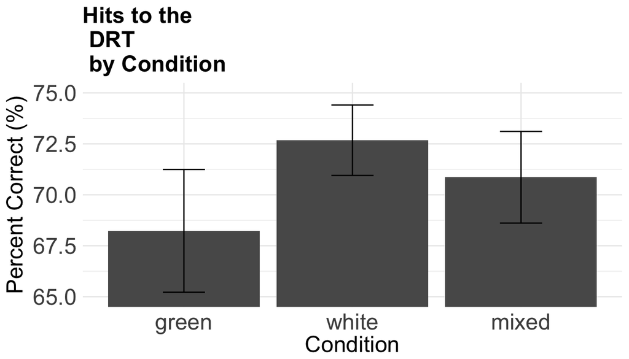

```r
drt.ac$condition <- recode_factor(drt.ac$condition,"1" = "practice","2" = "green","3" ="white", "4" = "mixed", .default = "NA")

drt.meanhit <- drt.ac %>%
  filter(response != -1) %>%
  dplyr::group_by(subid,condition) %>%
  dplyr::summarise(mean_ac_hits = mean(response)*100) %>%
  filter(condition != "practice", subid != "03", mean_ac_hits > 50)

drthit <- summarySEwithin(drt.meanhit, measurevar ="mean_ac_hits", withinvars = c("condition"), idvar = "subid")

drt.meanac <- drt.ac %>%
  filter(response != 0) %>%
  mutate(response = ifelse(response == "-1", 0,1)) %>%
  dplyr::group_by(subid,condition) %>%
  dplyr::summarise(mean_ac = mean(response)*100) %>%
  filter(condition != "practice", subid != "03")

drtac <- summarySEwithin(drt.meanac, measurevar ="mean_ac", withinvars = c("condition"), idvar = "subid")

hitplot <- ggplot(drthit, aes(x = condition, y=mean_ac_hits)) +
  geom_bar(stat = "identity",position = "dodge") + theme_minimal() +
  my.axis.font + geom_errorbar(width = .25,
                               aes(ymin=mean_ac_hits-ci, ymax=mean_ac_hits+ci)) +
  xlab("Condition") + coord_cartesian(ylim = c(65, 75)) +
  scale_fill_manual(values=myColors) + ylab("Percent Correct (%)") +
  ggtitle("Hits to the \n DRT \n by Condition")
hitplot
```

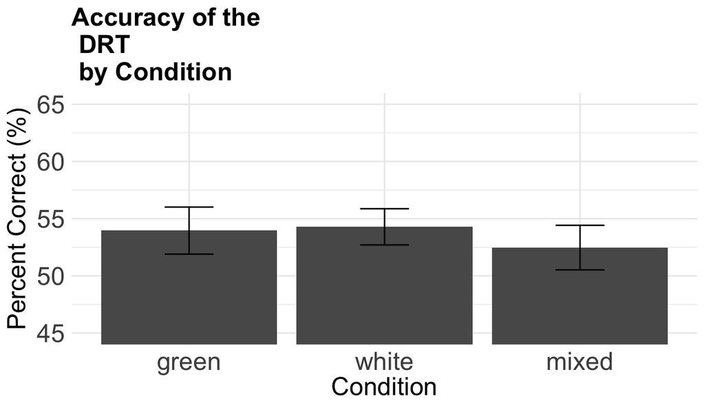

```r
drt.hit <- lmer(mean_ac_hits~condition+(1|subid),data=drt.meanhit)
Anova(drt.hit)


acplot <- ggplot(drtac, aes(x = condition, y=mean_ac)) +
  geom_bar(stat = "identity",position = "dodge") + theme_minimal() +
  my.axis.font + geom_errorbar(width = .25,
                               aes(ymin=mean_ac-ci, ymax=mean_ac+ci)) +
  xlab("Condition") + coord_cartesian(ylim = c(45, 65)) +
  scale_fill_manual(values=myColors) + ylab("Percent Correct (%)") +
  ggtitle("Accuracy of the \n DRT \n by Condition")
acplot
```

[output not shown]

```r
drt.ac1 <- lmer(mean_ac~condition+(1|subid),data=drt.meanac)
Anova(drt.ac1)
```

[output not shown]

Hits to the DRT correctly predicted the steering deviation across the 3 conditions.

### combined steering with drt

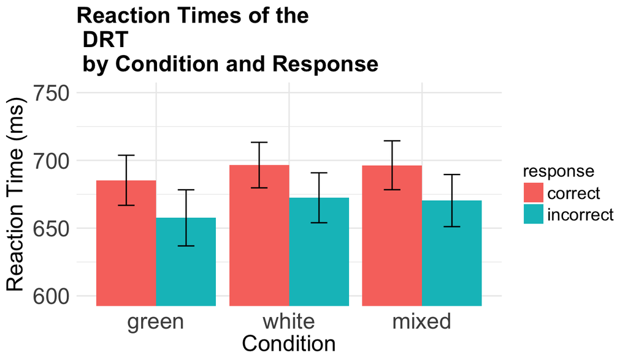

```r
drt.clean.choice$condition <- recode_factor(drt.clean.choice$condition,"1" = "practice","2" = "green","3" ="white", "4" = "mixed", .default = "NA")
drt.clean.choice$response <- recode_factor(drt.clean.choice$response, "1" = "correct", "-1" = "incorrect", "0" = "miss")

drtrt <- summarySEwithin(drt.clean.choice, measurevar ="rt", withinvars = c("condition","response"), idvar = "subid")

drtrt <- drtrt %>% filter(condition != "practice", response != "miss")

rtplot <- ggplot(drtrt, aes(x = condition, y=rt, fill = response)) +
  geom_bar(stat = "identity", position = "dodge") + theme_minimal() +
  my.axis.font + geom_errorbar(position=position_dodge(.9), width = .25,
                               aes(ymin=rt-ci, ymax=rt+ci)) +
  xlab("Condition") + coord_cartesian(ylim = c(600, 750)) + ylab("Reaction Time (ms)") +
  ggtitle("Reaction Times of the \n DRT \n by Condition and Response")
rtplot
```

```r
drt.rt <- lmer(rt~condition*response*mean.dev+(1|subid),data=drt.clean.choice)
Anova(drt.rt)
```

```
## Analysis of Deviance Table (Type II Wald chisquare tests)
##
## Response: rt
##                                Chisq Df Pr(>Chisq)
## condition                   376.6056  3    < 2e-16 ***
## response                    246.2230  2    < 2e-16 ***
## mean.dev                      0.2521  1    0.61561
## condition:response           16.6251  6    0.01076 *
## condition:mean.dev            8.0471  3    0.04505 *
## response:mean.dev             0.5400  2    0.76338
## condition:response:mean.dev   5.9518  6    0.42861
## ---
## Signif. codes:  0 '***' 0.001 '**' 0.01 '*' 0.05 '.' 0.1 ' ' 1
```

| condition | response | rt | ci |
| --- | --- | --- | --- |
| green | correct | 685 | 18 |
| green | incorrect | 657 | 20 |
| mixed | correct | 696 | 18 |
| mixed | incorrect | 670 | 19 |
| white | correct | 696 | 16 |
| white | incorrect | 672 | 18 |

Incorrect responses (where the participant responded to the light more than once) were faster on average than correct responses. The difficulty (condition) also affected reaction times. In addition, there was a difficulty (condition) by response interaction. We can see the effect of difficulty on steering below.

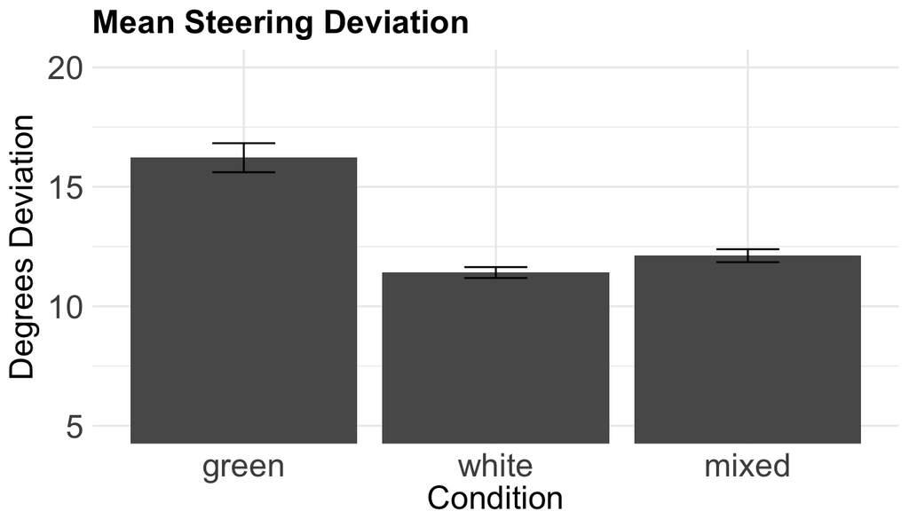

```r
drtrt <- summarySEwithin(drt.clean.choice, measurevar ="mean.dev", withinvars = c("condition"), idvar = "subid")

drtrt <- drtrt %>% filter(condition != "practice")

rtplot <- ggplot(drtrt, aes(x = condition, y=mean.dev)) +
  geom_bar(stat = "identity", position = "dodge") + theme_minimal() +
  my.axis.font + geom_errorbar(position=position_dodge(.9), width = .25,
                               aes(ymin=mean.dev-ci, ymax=mean.dev+ci)) +
  xlab("Condition") + coord_cartesian(ylim = c(5, 20)) + ylab("Degrees Deviation") +
  ggtitle("Mean Steering Deviation")
rtplot
```

```r
drt.rt <- lmer(mean.dev~condition+(1|subid),data=drt.clean.choice)
Anova(drt.rt)
```

[output not shown]

Alone, the effects of the difficulty of the visual task changed the steering deviation so that (1) at the easiest difficulty, steering was the worst (2) at the highest difficulty, steering was the best, and (3) when participants didn’t know whether to expect easy or difficult trials, steering was in between. In this case, participants may have been overloaded for the 3 tasks, and so priority could be given to a task that they thought they could complete.

```r
clean.choiceac %>%
  group_by(subid, condition) %>%
  dplyr::summarise(trials_completed = n())
```

```
## Source: local data frame [60 x 3]
## Groups: subid [?]
##
##     subid condition trials_completed
##    <fctr>    <fctr>            <int>
## 1      04     green              160
## 2      04     white              160
## 3      04     mixed              160
## 4      05     green              160
## 5      05     white              120
## 6      05     mixed              160
## 7      06     green              115
## 8      06     white              105
## 9      06     mixed              123
## 10     07     green              127
## # ... with 50 more rows
```